# Tidy data wrangling

## Tidy data

> *Все счастливые семьи похожи друг на друга, каждая несчастливая семья несчастлива по-своему.*

As Tolstoy write in Anna Karenina, “all happy families are alike; each unhappy family is unhappy in its own way.” The same is true of tidy data. All *tidy* datasets are alike; each untidy dataset is untidy in its own way. The three characteristics of tidy datasets are as follows:

- Each variable forms a column,
- Each observation forms a row, and
- Each type of observational unit forms a table.

Today’s dataset was posted to Kaggle by Mario Tormo Romero, who scraped the data from [the Pokemon Database](https://pokemondb.net) and [Serebii](https://www.serebii.net). It has been slightly modified for the purposes of this tutorial class.

The dataset contains information on all Pokemon, including alternate forms, through Generation 8 (Pokemon Sword and Shield). Pokemon have various characteristics unique to each one. The variables in the `pokemon` dataset are listed below.

- `pokedex_number`: a catelogue number of each Pokemon
- `generation`: which video game generation the Pokemon is from
- `leg_status`: whether a Pokemon is sub-legendary, legendary, mythical, or none
- `type_1`, `type_2`: what “type” a Pokemon is (fire, water, electric, etc.)
- `bst`: the base stat total of a Pokemon (a proxy for its effectiveness in combat)
- `hp`, `atk`, `def`, `spa`, `spd`, `spe`: a Pokemon’s battle statistics (HP, attack, defense, special attack, special defense, and speed, respectively)

[figure not shown]

The Pokemon depicted above is “Bulbasaur,” and is the first Pokemon listed in the National Pokedex. It is from Generation 1 (the first set of video games) and is a non-legendary Grass/Poison Pokemon. It is 0.7 meters tall, weights 6.9 kilograms, and has 318 total base stats (45 HP, 49 attack, 49 defense, 65 special attack, 65 special defense, and 45 speed).

## Factors in R

The tools for manipulating factors in base R are often unwieldy to use, and it is sometimes difficult to perform even basic factor-related tasks. Luckily, we can use the `forcats` package, a suite of tools in the `tidyverse` that perform common data wrangling tasks with factors in a tidy-data-conscious way.

Abilities include:

- Ordering by frequency
- Reordering factor levels
- Recoding factors
- Collapsing levels
- Lumping categories together
- …and more!

[figure not shown]

## Diving into forcats

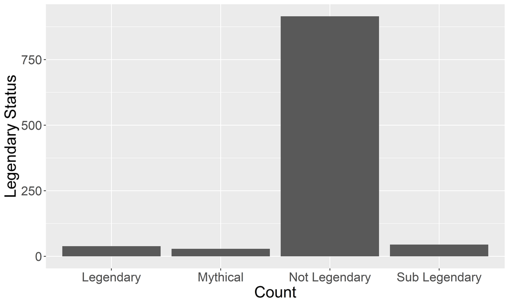

#### Ordering by frequency: `fct_infreq`

Note that by default, the bars are ordered alphabetically. One common data visualization task is to order our plot by frequency. We can easily do this using the `fct_infreq()` function. Examine the code used to create the following plot:

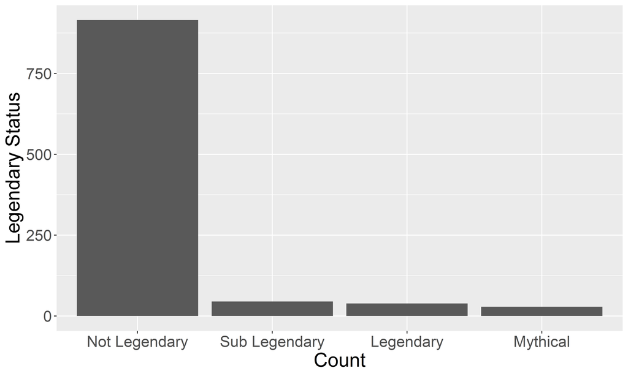

```r
ggplot(data = pokemon, mapping = aes(x = fct_infreq(leg_status))) +
  geom_bar() +
  labs(x = "Count", y = "Legendary Status")
```

#### Manually reordering levels: `fct_relevel`

We can also manually reorder the levels using the `fct_relevel()` function. For instance, let’s say we wanted to relevel the factor levels in order of decreasing “specialness.” We would use the following code:

```r
pokemon <- pokemon %>%
 mutate(leg_status = fct_relevel(leg_status,
                                 "Mythical",
                                 "Legendary",
                                 "Sub Legendary",
                                 "Not Legendary"))
```

And now any plot will now show those factor levels as the default order:

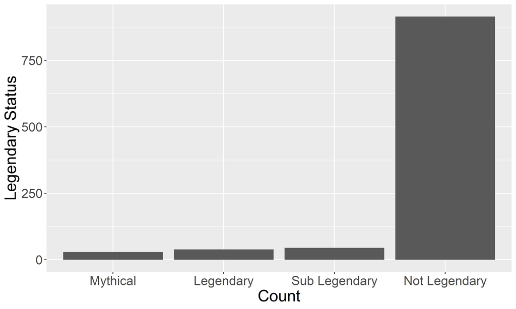

#### Manually recoding factors: `fct_recode`

Another common task is to manually recode factor levels. That is, change existing factor levels to new labels. For instance, let’s suppose we wanted to recode the `leg_status` variable such that legendary and mythical Pokemon are tagged as legendary, and non- or sub-legendary Pokemon are not. We may use the following code to do so:

```r
pokemon <- pokemon %>%
 mutate(binary_leg = fct_recode(leg_status,
                              "No" = "Not Legendary",
                              "No" = "Sub Legendary",
                              "Yes" = "Legendary",
                              "Yes" = "Mythical"))
```

Let’s verify it worked:

```
## # A tibble: 2 x 2
##   binary_leg     n
##   <fct>      <int>
## 1 Yes           68
## 2 No           960
```

#### Collapsing levels: `fct_collapse`

Similarly, we can combine many factor levels into one by using the `fct_collapse()` function. Let’s do the same task as the previous example, this time using `fct_collapse()`:

```r
pokemon <- pokemon %>%
 mutate(collapse_leg = fct_collapse(leg_status,
                              no = c("Not Legendary", "Sub Legendary"),
                              yes = c("Legendary", "Mythical")))
```

And let’s verify that the code worked here as well:

```
## # A tibble: 2 x 2
##   collapse_leg     n
##   <fct>        <int>
## 1 yes             68
## 2 no             960
```

#### Lumping categories together: `fct_lump`

A final often-performed command is to lump less common categories together (perhaps in an “Other” category). `fct_lump()` allows us to do so by either defining the absolute number of categories or by looking at relative proportions of the whole. For instance, the following code would allow us to lump all Pokemon whose primary types (`type_1`) that aren’t in the top 5 most common as “Other” (and create a new variable called `prim_type` along the way):

```r
pokemon %>%
 mutate(prim_type = fct_lump(type_1, n = 5))
```

Similarly, the following code allows us to lump any Pokemon whose primary type (`type_1`) doesn’t comprise at least 5% of the whole into a separate “Other” category. Once again, we’re creating a new variable, `prim_type`:

```r
pokemon %>%
 mutate(prim_type = fct_lump(type_1, prop = 0.05))
```

## On your own!

The following exercises are designed to familiarize you with operations on categorical variables in R.

Load in the `pokemon` dataset with the following code. As well, load in the `tidyverse`, which contains `dplyr` as part of it.

```r
library(tidyverse)
pokemon <- read_csv("data/pokemon.csv")
```